# MACS 30200: Problem Set 3

Dongping Zhang

5/15/2017

# Part I. Regression diagnostics

**0. Estimate the following linear regression model of attitudes towards Joseph Biden:**
$$Y = \beta_0 + \beta_1X_1 + \beta_2X_2 + \beta_3X_3$$
**where Y is the Joe Biden feeling thermometer, X1 is age, X2 is gender, and X3 is education. Report the parameters and standard errors.**

- Load the biden dataset, clean missing values, and process variables

```r
biden_df = read.csv("biden.csv") %>%
  na.omit() %>%
  mutate(dem = factor(dem),
         rep = factor(rep))
```

- Run a regression of `age`, `gender` and `education` on `feeling thermometer score`

```r
biden_lm <- lm(biden ~ age + female + educ, data = biden_df)
```

- Report the OLS regression model

```r
tidy(biden_lm)
```

```
##          term estimate std.error statistic  p.value
## 1 (Intercept)  68.6210    3.5960     19.08 4.34e-74
## 2         age   0.0419    0.0325      1.29 1.98e-01
## 3      female   6.1961    1.0967      5.65 1.86e-08
## 4        educ  -0.8887    0.2247     -3.96 7.94e-05
```

The parameters and standard errors of the model are listed in the regression table above. As we can see from the p-values, except coefficient for the `age` variable, all coefficients are statistically significant at 5% significance level.

**1. Test the model to identify any unusual and/or influential observations. Identify how you would treat these observations moving forward with this research. Note you do not actually have to estimate a new model, just explain what you would do. This could include things like dropping observations, respecifying the model, or collecting additional variables to control for this influential effect.**

- adding key statistics: leverage, discrepancy, and influence

```r
biden_augment = biden_df %>%
  mutate(hat = hatvalues(biden_lm),  # leverage (hat) statistics
         student = rstudent(biden_lm), # measuring discripancy
         cooksd = cooks.distance(biden_lm)) # measuring influence
```

- Pick out the problematics:
  - For leverages statistics, anything exceeding twice the average is noteworthy

  ```r
  hat_benchmark = 2 * mean(biden_augment$hat)
  ```

  - For discrepancy statistics, anything outside of the range [-2,2] is discrepant
  - For influence statistics, Cook’s D greater than $\frac{4}{n - k - 1}$ is influential

  ```r
  cooksd_benchmark = 4 / (nrow(biden_augment) - (length(coef(biden_lm)) - 1) - 1)
  ```

  - Pickout the problematic obs

  ```r
  problematics = biden_augment %>%
  filter(hat > hat_benchmark |
         abs(student) > 2 |
         cooksd > cooksd_benchmark)
  ```

- For the sake of plotting, need to add a `diagonistic` column to the `problematics` dataframe created above

```r
diaganostic = c()
for (i in 1:nrow(problematics)){
  if(problematics[i,]$hat > hat_benchmark){
    problem = 'high leverage'
  }
  if(abs(problematics[i,]$student) > 2){
    problem = 'high discrepancy'
  }
  if(problematics[i,]$cooksd > cooksd_benchmark){
    problem = 'high influence'
  }
  if (problematics[i,]$hat > hat_benchmark &
      abs(problematics[i,]$student) > 2){
    problem = 'high leverage, high discrepancy'
  }
  if (problematics[i,]$hat > hat_benchmark &
      problematics[i,]$cooksd > cooksd_benchmark){
    problem = 'high leverage, high influence'
  }
  if (abs(problematics[i,]$student) > 2 &
      problematics[i,]$cooksd > cooksd_benchmark){
    problem = 'high discrepancy, high influence'
  }
  if (problematics[i,]$hat > hat_benchmark &
      abs(problematics[i,]$student) > 2 &
      problematics[i,]$cooksd > cooksd_benchmark){
    problem = 'high leverage, high discrepancy, \nhigh influence'
  }
  diaganostic = c(diaganostic, problem)
}

# append it to the dataframe problematic
problematics = problematics %>%
  mutate(problem = factor(diaganostic))
```

- visualizing leverage, discrepancy, and influence by a “bubble plot”

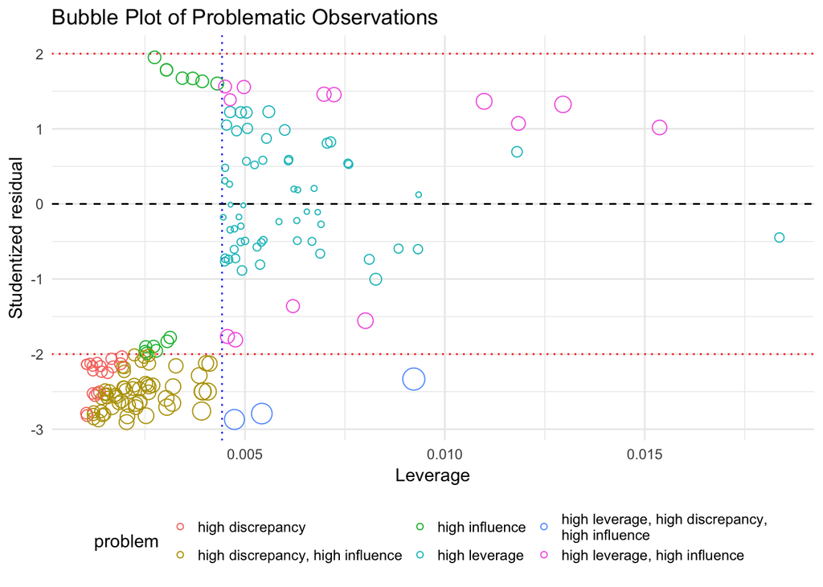

```r
ggplot(problematics, aes(hat, student)) +
  geom_hline(yintercept = 0, linetype = 2) +
  geom_hline(yintercept = 2, linetype = 3, color = 'red') +
  geom_hline(yintercept = -2, linetype = 3, color = 'red') +
  geom_vline(xintercept = hat_benchmark, linetype = 3, color = 'blue') +
  geom_point(aes(size = cooksd, color = problem), shape = 1) +
  scale_size_continuous(range = c(1, 50)) +
  labs(title = "Bubble Plot of Problematic Observations",
       x = "Leverage",
       y = "Studentized residual") +
  scale_size(guide = "none") +
  theme(legend.position="bottom")
```

- To find a solution dealing with those problematic obs, aggregate those problematic points with other variables to see if there are any potential patterns
  - identify all problematic points

  ```r
  for (i in 1:nrow(biden_augment)){
    if(biden_augment[i,]$hat > hat_benchmark |
       abs(biden_augment[i,]$student) > 2 |
       biden_augment[i,]$cooksd > cooksd_benchmark){
        biden_augment$problem[i] = "Yes"
      }else{
        biden_augment$problem[i] = "No"
      }
  }
  biden_augment$problem = factor(biden_augment$problem)
  biden_augment$female = factor(biden_augment$female)
  ```

  - Start plotting

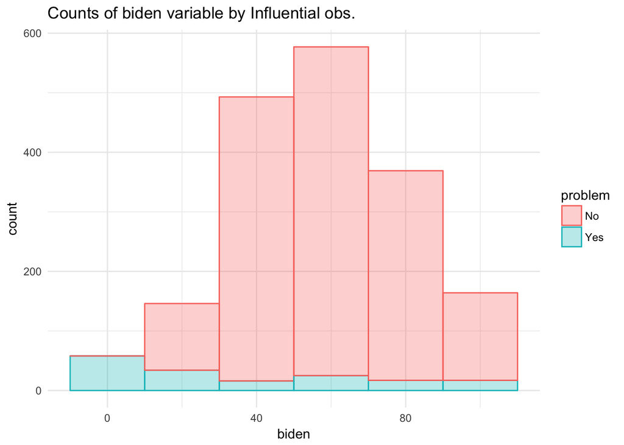

  ```r
  # biden
  ggplot(biden_augment, aes(biden)) +
    geom_histogram(aes(color = problem, fill = problem),
                   binwidth = 20, alpha = 0.3) +
    labs(title = "Counts of biden variable by Influential obs.")
  ```

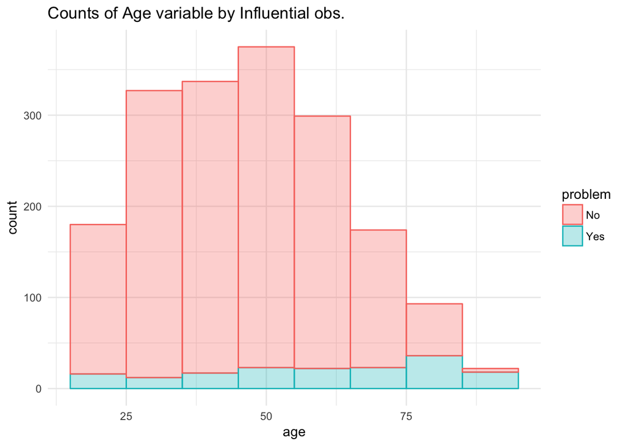

  ```r
  # age
  ggplot(biden_augment, aes(age)) +
    geom_histogram(aes(color = problem, fill = problem),
                   binwidth = 10, alpha = 0.3) +
    labs(title = "Counts of Age variable by Influential obs.")
  ```

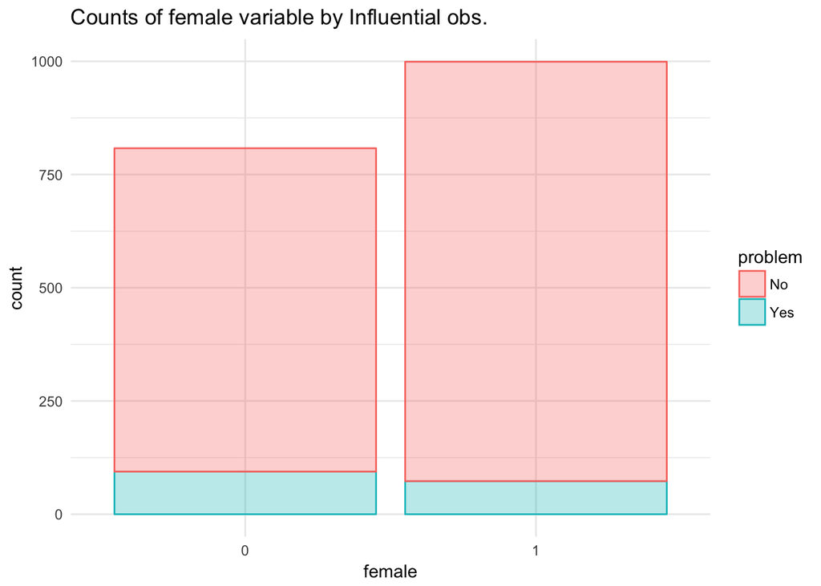

  ```r
  # female
  ggplot(biden_augment, aes(female)) +
    geom_bar(aes(color = problem, fill = problem),
                   stat = "count", alpha = 0.3) +
    labs(title = "Counts of female variable by Influential obs.")
  ```

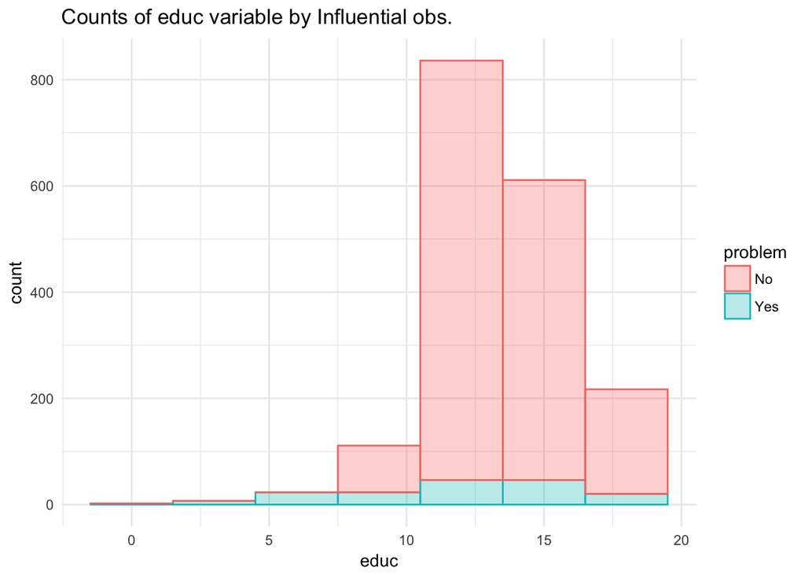

  ```r
  # educ
  ggplot(biden_augment, aes(educ)) +
    geom_histogram(aes(color = problem, fill = problem),
                   binwidth = 3, alpha = 0.3) +
    labs(title = "Counts of educ variable by Influential obs.")
  ```

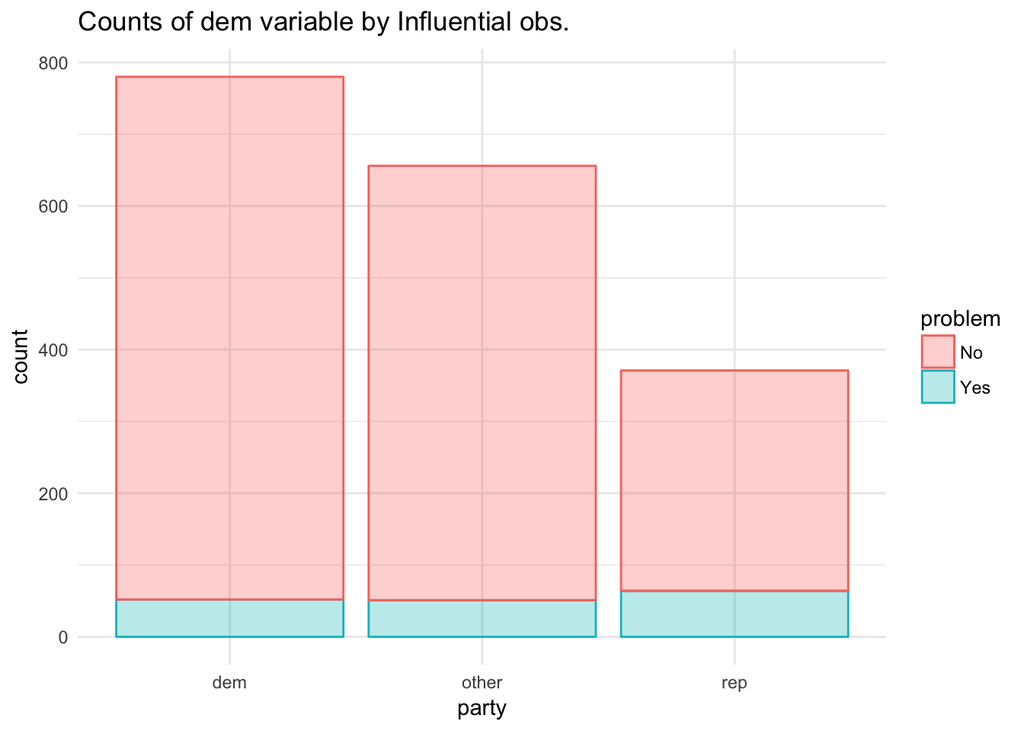

  ```r
  # party
  for (i in 1:nrow(biden_augment)){
    if (biden_augment[i,]$dem == 1){
      biden_augment$party[i] = 'dem'
    }else if(biden_augment[i,]$rep == 1){
      biden_augment$party[i] = 'rep'
    }else{
      biden_augment$party[i] = 'other'
    }
  }
  biden_augment$party = factor(biden_augment$party)
  ggplot(biden_augment, aes(party)) +
    geom_bar(aes(color = problem, fill = problem),
                   stat = "count", alpha = 0.3) +
    labs(title = "Counts of dem variable by Influential obs.")
  ```

In conclusion, according to the variable aggregation plots above, it is diffcult to detect any potential data anomalies from data collection process. On the other hand, we are able to see that unusual observation are more likely to occur to individuals with low biden thermometer score, older males who received lower education (percentage wise), and people who are republicans. To treat those unusual observations and to move forward, I would add a party predictor to the model so as to indicate party affiliation. At the same time, selected interaction terms among `female`, `educ`, and `age` should also be included in the model in order to account for potential interaction effect.

**2. Test for non-normally distributed errors. If they are not normally distributed, propose how to correct for them.**

- Plot a quantile-comparison plot and assess violation of constant variance by graphical interpretation

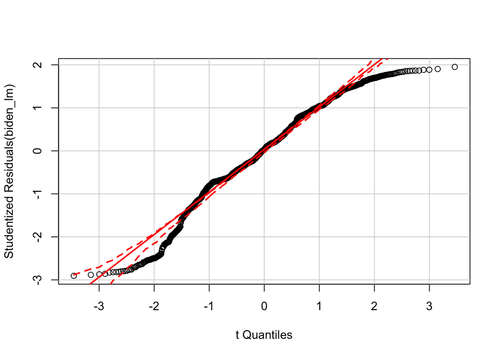

```r
car::qqPlot(biden_lm)
```

The dashed lines indicate 95% confidence intervals calculated under the assumption that the errors are normally distributed, and if any observations fall outside of this range, it would be an indication of violation of constant variance assumption. Clearly, assumption of constant variance is violated.

- To get a degree of residual skewness, plot a density plot of the studentized residuals

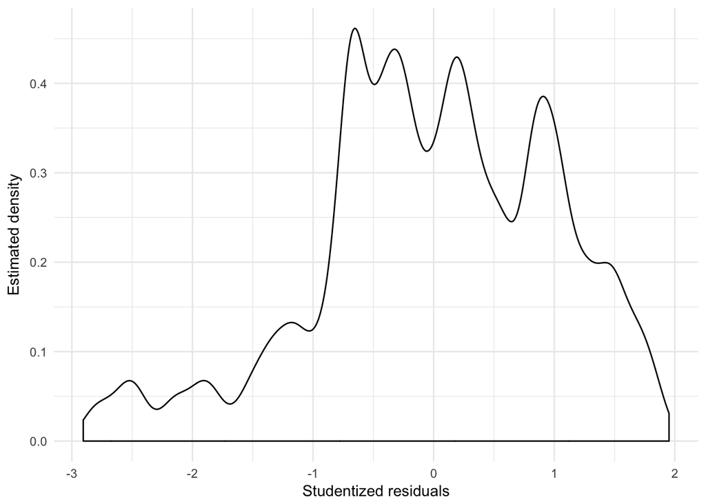

```r
augment(biden_lm, biden_df) %>%
  mutate(.student = rstudent(biden_lm)) %>%
  ggplot(aes(.student)) +
  geom_density(adjust = .5) +
  labs(x = "Studentized residuals",
       y = "Estimated density")
```

From the density plot of the studentized residuals, we can also see that the residuals are negatively skewed.

- Use box-cox to get a sense of suitable transformation, and from the plot below, a power transformation of 1.2 might be working the best

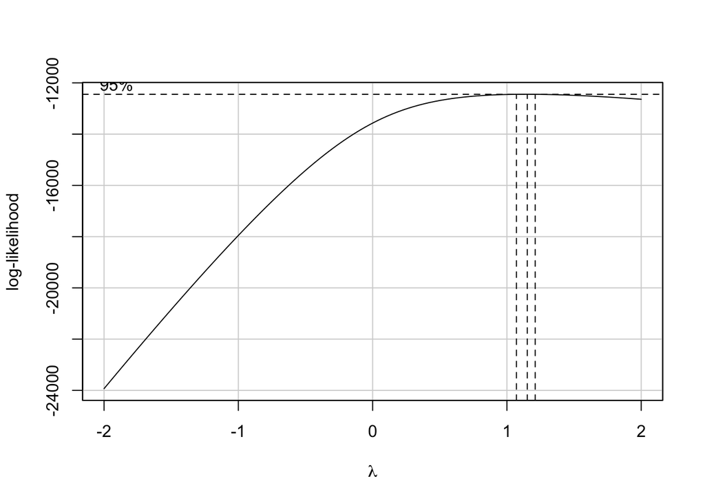

```r
biden_lm2 = lm(biden + 1 ~ age + female + educ, data = biden_df)
boxCox(biden_lm2)
```

- Use power transformation to see potential improvement

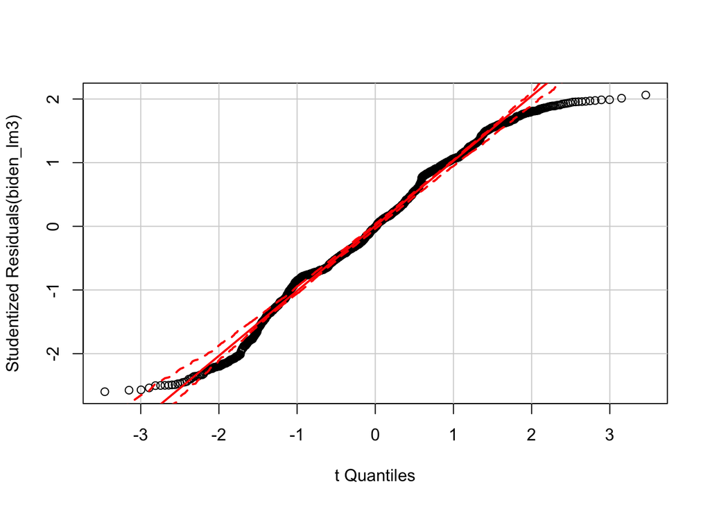

```r
biden_lm3 = lm(biden^1.2 ~ age + female + educ, data = biden_df)
car::qqPlot(biden_lm3)
```

- check residual skewness again

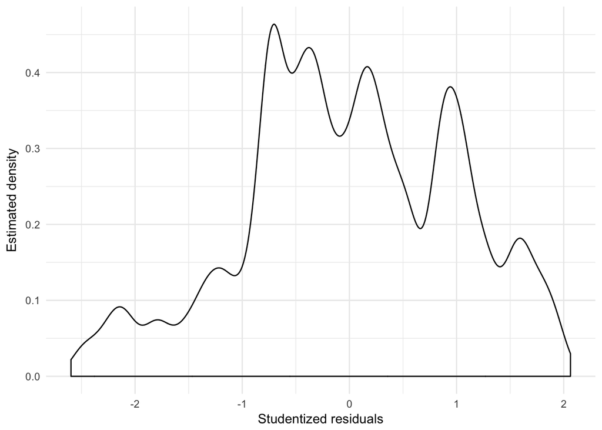

```r
augment(biden_lm3, biden_df) %>%
  mutate(.student = rstudent(biden_lm3)) %>%
  ggplot(aes(.student)) +
  geom_density(adjust = .5) +
  labs(x = "Studentized residuals",
       y = "Estimated density")
```

According to the pairs of plots below, after power transformation, the standarized residuals are still negatively skewed but looked definitely much better. However, there is no guarantee that the assumption of constant variance would be completely reached, however, using box-cox to get a sense of transformation should always be the priority method.

**3. Test for heteroscedasticity in the model. If present, explain what impact this could have on inference.**

- Visually assess heteroscedasticity by residual-predicted value plot

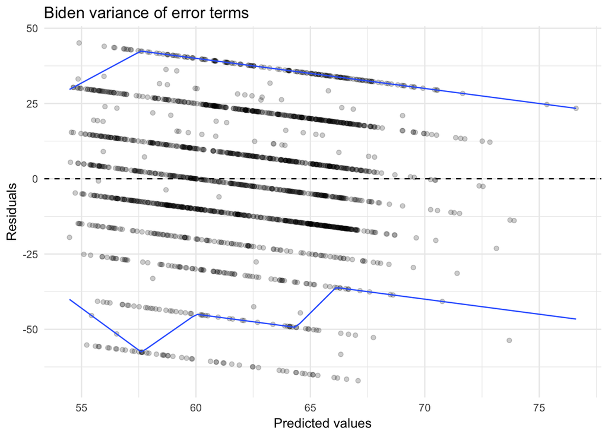

```r
biden_df %>%
  select(-c(dem, rep)) %>%
  add_predictions(biden_lm) %>%
  add_residuals(biden_lm) %>%
  ggplot(aes(pred, resid)) +
  geom_point(alpha = .2) +
  geom_hline(yintercept = 0, linetype = 2) +
  geom_quantile(method = "rqss", lambda = 5, quantiles = c(.05, .95)) +
  labs(title = "Biden variance of error terms",
       x = "Predicted values",
       y = "Residuals")
```

- Use Breusch-Pagan test to assess heteroscedasticity of the current `biden_lm` model

```r
bptest(biden_lm)
```

```
##
##  studentized Breusch-Pagan test
##
## data:  biden_lm
## BP = 20, df = 3, p-value = 5e-05
```

Because the p-value is 0.00005, which is smaller than $\alpha = 0.05$ significance level, thus we reject $H_0$ of homoscedasticity and thus heteroscedasticity is present.

When heteroscedasticity is present, OLS is not optimal because it would still give equal weight to all observations when, in fact, observations with larger disturbance variance contain less information than observations with smaller disturbance variance. Thus, standard errors are also biased when heteroskedasticity is present. This in turn leads to bias in test statistics and confidence intervals.

**4. Test for multicollinearity. If present, propose if/how to solve the problem.** * To test for multicollinearity, use variance inflation factor (vif)

```r
vif(biden_lm)
```

```
##    age female   educ
##   1.01   1.00   1.01
```

In conclusion, because the vif statistics for all three variables are less then 10, thus we can claim that there is not potential multicolinearity.

- To test of pair-wise collinearity by using a scatterplot matrix

```r
cormat_heatmap <- function(data){
  # generate correlation matrix
  cormat <- round(cor(data), 2)

  # melt into a tidy table
  get_upper_tri <- function(cormat){
    cormat[lower.tri(cormat)]<- NA
    return(cormat)
  }

  upper_tri <- get_upper_tri(cormat)

  # reorder matrix based on coefficient value
  reorder_cormat <- function(cormat){
    # Use correlation between variables as distance
    dd <- as.dist((1-cormat)/2)
    hc <- hclust(dd)
    cormat <-cormat[hc$order, hc$order]
  }

  cormat <- reorder_cormat(cormat)
  upper_tri <- get_upper_tri(cormat)

  # Melt the correlation matrix
  melted_cormat <- reshape2::melt(upper_tri, na.rm = TRUE)

  # Create a ggheatmap
  ggheatmap <- ggplot(melted_cormat, aes(Var2, Var1, fill = value))+
    geom_tile(color = "white")+
    scale_fill_gradient2(low = "blue", high = "red", mid = "white",
                         midpoint = 0, limit = c(-1,1), space = "Lab",
                         name="Pearson\nCorrelation") +
    theme_minimal()+ # minimal theme
    theme(axis.text.x = element_text(angle = 45, vjust = 1,
                                     size = 12, hjust = 1))+
    coord_fixed()

  # add correlation values to graph
  ggheatmap +
    geom_text(aes(Var2, Var1, label = value), color = "black", size = 4) +
    theme(
      axis.title.x = element_blank(),
      axis.title.y = element_blank(),
      panel.grid.major = element_blank(),
      panel.border = element_blank(),
      panel.background = element_blank(),
      axis.ticks = element_blank(),
      legend.position = "bottom")
}
```

- To check pair-wise collinearity

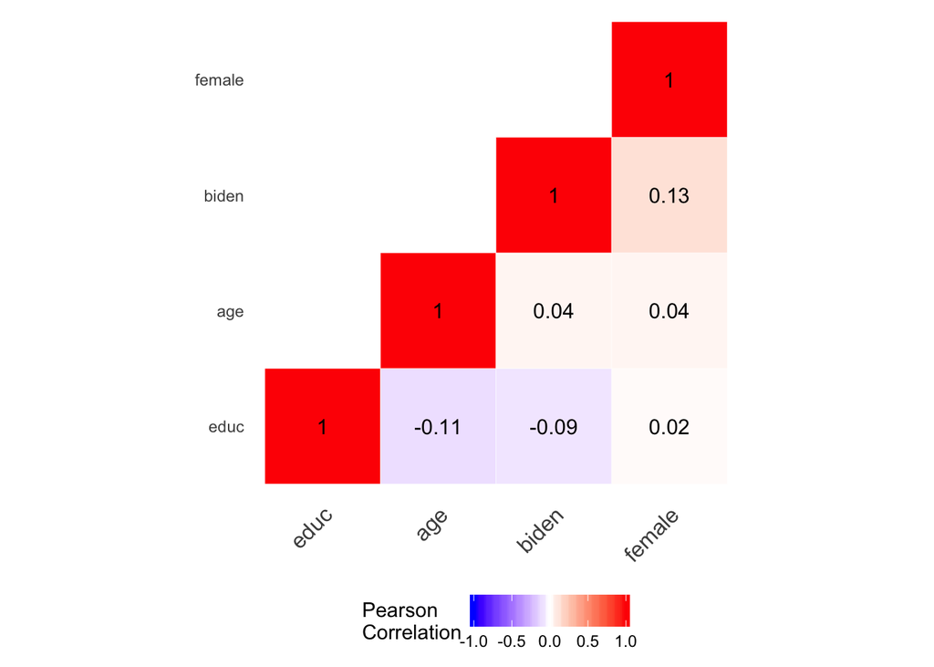

```r
cormat_heatmap(select_if(biden_df, is.numeric))
```

In conclusion, there is also no significant collinearity among pairwie variables.

If multicollinearity present, we could try to solve the problem by: adding more data to decrease standard error, transform the covariates, and to use shrinkage methods.

# Part II. Interaction terms

**1. Evaluate the marginal effect of age on Joe Biden thermometer rating, conditional on education. Consider the magnitude and direction of the marginal effect, as well as its statistical significance.** * Regress `age`, `educ`, and their interaction term on `biden`

```r
biden_interaction = lm(biden ~ age * educ, data = biden_df)
tidy(biden_interaction)
```

```
##          term estimate std.error statistic  p.value
## 1 (Intercept)   38.374    9.5636      4.01 6.25e-05
## 2         age    0.672    0.1705      3.94 8.43e-05
## 3        educ    1.657    0.7140      2.32 2.04e-02
## 4    age:educ   -0.048    0.0129     -3.72 2.03e-04
```

- Compose a function to get point estimates and standard errors

```r
instant_effect <- function(model, mod_var){
  # get interaction term name
  int.name <- names(model$coefficients)[[which(str_detect(names(model$coefficients), ":"))]]

  marg_var <- str_split(int.name, ":")[[1]][[which(str_split(int.name, ":")[[1]] != mod_var)]]

  # store coefficients and covariance matrix
  beta.hat <- coef(model)
  cov <- vcov(model)

  # possible set of values for mod_var
  if(class(model)[[1]] == "lm"){
    z <- seq(min(model$model[[mod_var]]), max(model$model[[mod_var]]))
  } else {
    z <- seq(min(model$data[[mod_var]]), max(model$data[[mod_var]]))
  }

  # calculate instantaneous effect
  dy.dx <- beta.hat[[marg_var]] + beta.hat[[int.name]] * z

  # calculate standard errors for instantaeous effect
  se.dy.dx <- sqrt(cov[marg_var, marg_var] +
                     z^2 * cov[int.name, int.name] +
                     2 * z * cov[marg_var, int.name])

  # combine into data frame
  data_frame(z = z,
             dy.dx = dy.dx,
             se = se.dy.dx)
}
```

- Plot the marginal effect of age

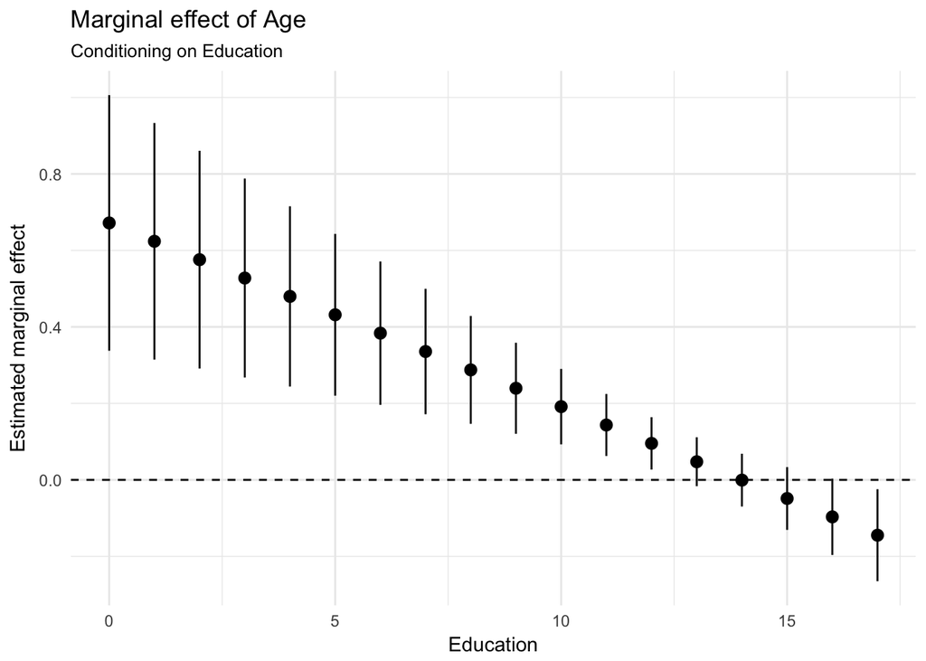

```r
instant_effect(biden_interaction, "educ") %>%
  ggplot(aes(z, dy.dx,
             ymin = dy.dx - 1.96 * se,
             ymax = dy.dx + 1.96 * se)) +
  geom_pointrange() +
  geom_hline(yintercept = 0, linetype = 2) +
  labs(title = "Marginal effect of Age",
       subtitle = "Conditioning on Education",
       x = "Education",
       y = "Estimated marginal effect")
```

The plot above shows the marginal effect of age, conditioning on education, and its confidence interval. According to the marginal effect plot, it can be observed that marginal effect of age is positive if the observation has less than 14 years of education and is negative if the observation has more than 14 years of education.

- To test the significance of marginal effect, conduct hypothesis testing on our estimates

```r
linearHypothesis(biden_interaction, "age + age:educ")
```

```
## Linear hypothesis test
##
## Hypothesis:
## age  + age:educ = 0
##
## Model 1: restricted model
## Model 2: biden ~ age * educ
##
##   Res.Df    RSS Df Sum of Sq    F Pr(>F)
## 1   1804 985149
## 2   1803 976688  1      8461 15.6  8e-05 ***
## ---
## Signif. codes:  0 '***' 0.001 '**' 0.01 '*' 0.05 '.' 0.1 ' ' 1
```

As shown above, because the p-value is 0.00008, which is less than 5% significance level, thus we can claim the marginal effect of age is statistically significant.

**2. Evaluate the marginal effect of education on Joe Biden thermometer rating, conditional on age. Consider the magnitude and direction of the marginal effect, as well as its statistical significance.** * Plot the marginal effect of education

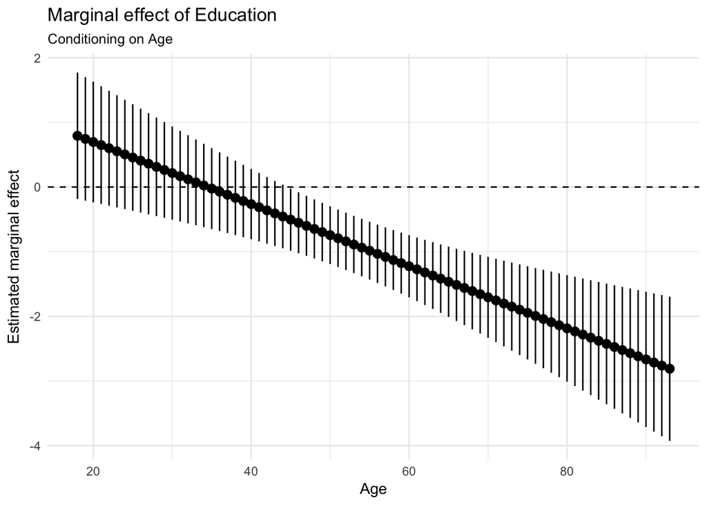

```r
instant_effect(biden_interaction, "age") %>%
  ggplot(aes(z, dy.dx,
             ymin = dy.dx - 1.96 * se,
             ymax = dy.dx + 1.96 * se)) +
  geom_pointrange() +
  geom_hline(yintercept = 0, linetype = 2) +
  labs(title = "Marginal effect of Education",
       subtitle = "Conditioning on Age",
       x = "Age",
       y = "Estimated marginal effect")
```

The plot above shows the marginal effect of education, conditioning on age, and its confidence interval. According to the marginal effect plot, it can be observed that marginal effect of education is positive if the observation is less than 35 years old and is negative if the observation is more than 35 years old.

- To test the significance of marginal effect, conduct hypothesis testing on our estimates

```r
linearHypothesis(biden_interaction, "educ + age:educ")
```

```
## Linear hypothesis test
##
## Hypothesis:
## educ  + age:educ = 0
##
## Model 1: restricted model
## Model 2: biden ~ age * educ
##
##   Res.Df    RSS Df Sum of Sq    F Pr(>F)
## 1   1804 979537
## 2   1803 976688  1      2849 5.26  0.022 *
## ---
## Signif. codes:  0 '***' 0.001 '**' 0.01 '*' 0.05 '.' 0.1 ' ' 1
```

# Part III. Missing data

**1. Estimate the following linear regression model of attitudes towards Joseph Biden:**

$$Y = \beta_0 + \beta_1X_1 + \beta_2X_2 + \beta_3X_3$$

**where Y is the Joe Biden feeling thermometer, X1 is age, X2 is gender, and X3 is education. This time, use multiple imputation to account for the missingness in the data. Consider the multivariate normality assumption and transform any variables as you see fit for the imputation stage. Calculate appropriate estimates of the parameters and the standard errors and explain how the results differ from the original, non-imputed model.**

- load `biden` dataset again without removing NAs

```r
biden = read.csv("biden.csv") %>%
  mutate(female = factor(female))
```

- Regress `age`, `female`, and `educ` on `biden`

```r
biden_MIA = lm(biden ~ age + female + educ, data = biden)
tidy(biden_MIA)
```

```
##          term estimate std.error statistic  p.value
## 1 (Intercept)  67.5579    3.5638     18.96 2.76e-73
## 2         age   0.0432    0.0323      1.34 1.81e-01
## 3     female1   6.0221    1.0899      5.53 3.76e-08
## 4        educ  -0.8146    0.2222     -3.67 2.53e-04
```

- Find the number of missing data

```r
biden %>%
  select(biden, age, female, educ) %>%
  summarize_all(funs(sum(is.na(.)))) %>%
  knitr::kable()
```

| biden | age | female | educ |
| --- | --- | --- | --- |
| 460 | 46 | 0 | 11 |

- So want to check which variables are highly correlated with age and educ so as to include in the imputation model

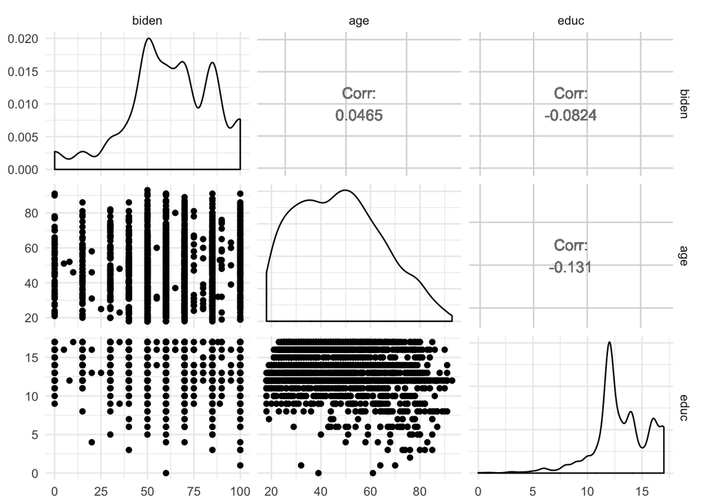

```r
biden %>%
  select(biden, age, educ) %>%
  GGally::ggpairs(select_if(., is.numeric))
```

- We can see `age` and `educ` are clearly not normally distributed, so transform those variables when imputation

```r
biden_transform = biden %>%
  mutate(age = age,
         power_educ = educ^2)
```

- show correlation of transformed variables

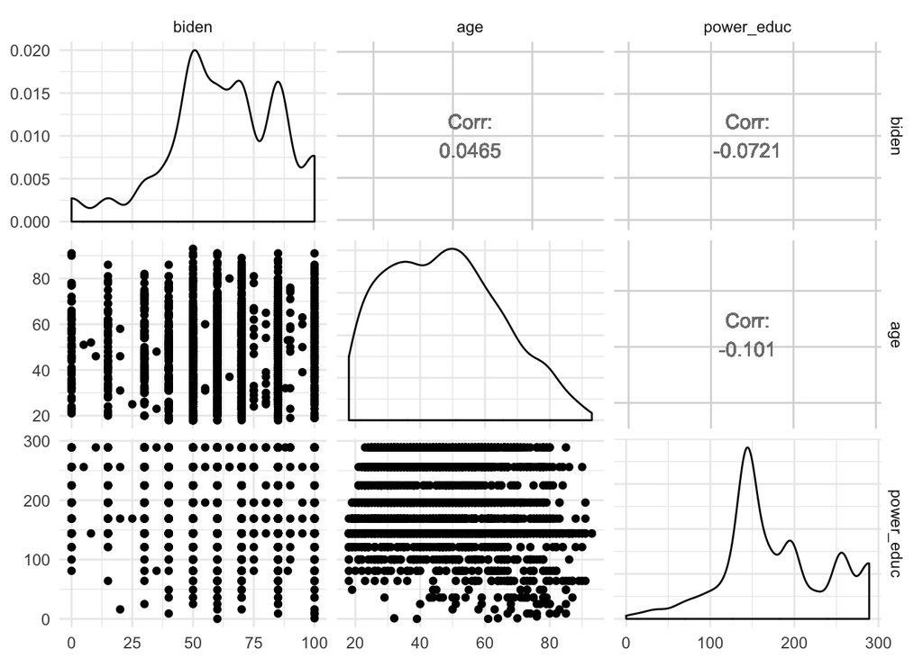

```r
biden_transform %>%
  select(biden, age, power_educ) %>%
  GGally::ggpairs(select_if(., is.numeric))
```

- Use multiple imputation to account for the missingness in the data

```r
biden.out <- amelia(as.data.frame(biden_transform), m = 5,
                    idvars = c("female", "dem", "rep", "educ", "age"))
```

- Now checking out what the new model is like

```r
models_trans_imp <- data_frame(data = biden.out$imputations) %>%
  mutate(model = map(data, ~ lm(biden ~ age + power_educ + female,
                                data = .x)),
         coef = map(model, tidy)) %>%
  unnest(coef, .id = "id")

models_trans_imp
```

```
## # A tibble: 20 x 6
##       id        term estimate std.error statistic   p.value
##    <chr>       <chr>    <dbl>     <dbl>     <dbl>     <dbl>
##  1  imp1 (Intercept)  61.2167   2.11343     28.97 2.83e-157
##  2  imp1         age   0.0379   0.02808      1.35  1.77e-01
##  3  imp1  power_educ  -0.0201   0.00763     -2.63  8.52e-03
##  4  imp1     female1   4.5520   0.97923      4.65  3.53e-06
##  5  imp2 (Intercept)  63.5935   2.10167     30.26 2.77e-169
##  6  imp2         age   0.0300   0.02790      1.08  2.82e-01
##  7  imp2  power_educ  -0.0312   0.00758     -4.12  4.00e-05
##  8  imp2     female1   4.8136   0.97266      4.95  8.01e-07
##  9  imp3 (Intercept)  63.1662   2.12446     29.73 2.25e-164
## 10  imp3         age   0.0307   0.02825      1.09  2.77e-01
## 11  imp3  power_educ  -0.0272   0.00766     -3.55  3.97e-04
## 12  imp3     female1   4.5642   0.98535      4.63  3.83e-06
## 13  imp4 (Intercept)  61.6391   2.12494     29.01 1.17e-157
## 14  imp4         age   0.0390   0.02820      1.38  1.67e-01
## 15  imp4  power_educ  -0.0225   0.00767     -2.93  3.42e-03
## 16  imp4     female1   4.6164   0.98354      4.69  2.84e-06
## 17  imp5 (Intercept)  63.8486   2.11786     30.15 3.02e-168
## 18  imp5         age   0.0316   0.02813      1.12  2.61e-01
## 19  imp5  power_educ  -0.0301   0.00764     -3.94  8.36e-05
## 20  imp5     female1   4.1639   0.98102      4.24  2.28e-05
```

```r
mi.meld.plus <- function(df_tidy){
  # transform data into appropriate matrix shape
  coef.out <- df_tidy %>%
    select(id:estimate) %>%
    spread(term, estimate) %>%
    select(-id)

  se.out <- df_tidy %>%
    select(id, term, std.error) %>%
    spread(term, std.error) %>%
    select(-id)

  combined.results <- mi.meld(q = coef.out, se = se.out)

  data_frame(term = colnames(combined.results$q.mi),
             estimate.mi = combined.results$q.mi[1, ],
             std.error.mi = combined.results$se.mi[1, ])
}

(biden_imputed = mi.meld.plus(models_trans_imp))
```

```
## # A tibble: 4 x 3
##          term estimate.mi std.error.mi
##         <chr>       <dbl>        <dbl>
## 1 (Intercept)     62.6928      2.48549
## 2         age      0.0339      0.02849
## 3     female1      4.5420      1.01389
## 4  power_educ     -0.0262      0.00928
```

- Now compare the imputed model with nonimputed model.
  - left side: non-imputed model
  - right: imputed model

```r
tidy(biden_MIA) %>%
  select(term, estimate, std.error)%>%
  cbind(biden_imputed)
```

```
##          term estimate std.error        term estimate.mi std.error.mi
## 1 (Intercept)  67.5579    3.5638 (Intercept)     62.6928      2.48549
## 2         age   0.0432    0.0323         age      0.0339      0.02849
## 3     female1   6.0221    1.0899     female1      4.5420      1.01389
## 4        educ  -0.8146    0.2222  power_educ     -0.0262      0.00928
```